# Упражнение 7

Владимиров Андрей

09 05 2021

Нелинейные модели Необходимо построить две модели:

- зависимости непрерывного отклика от одного непрерывного предиктора;
- зависимости вероятности (логит) от одного непрерывного предиктора.

Для каждой модели:

1 Указать смысл переменных модели, метод оценки и настроечный параметр (степень полинома, гиперпараметр λ, ширина окна s, число узлов – в зависимости от метода).

2 Подогнать модель на всех наблюдениях, меняя значение настроечного параметра.

3 Обосновать оптимальное значение настроечного параметра подходящим методом (кросс-валидация, ANOVA).

4 Сделать прогноз на обучающую выборку по лучшей модели: модельные значения и ошибки прогноза.

5 Построить график с фактическими наблюдениями, модельной кривой и 95% доверительными интервалами прогноза.

В таблице ниже указаны набор данных, столбцы с переменными для модели и метод подгонки.

Как сдавать: прислать на почту преподавателя ссылки:

- на html-отчёт с видимыми блоками кода (блоки кода с параметром echo = T), размещённый на rpubs.com.
- на код, генерирующий отчёт, в репозитории на github.com. В текст отчёта включить постановку задачи и ответы на вопросы задания.

# Вариант - 8

Модели: локальная регрессия.

Данные: *`Auto {ISLR}’*.

```r
attach(Auto)
```

Работаем со столбцами:

- *displacement* – Объем двигателя (куб. дюймов);
- *weight* – Масса автомобиля (кг.).

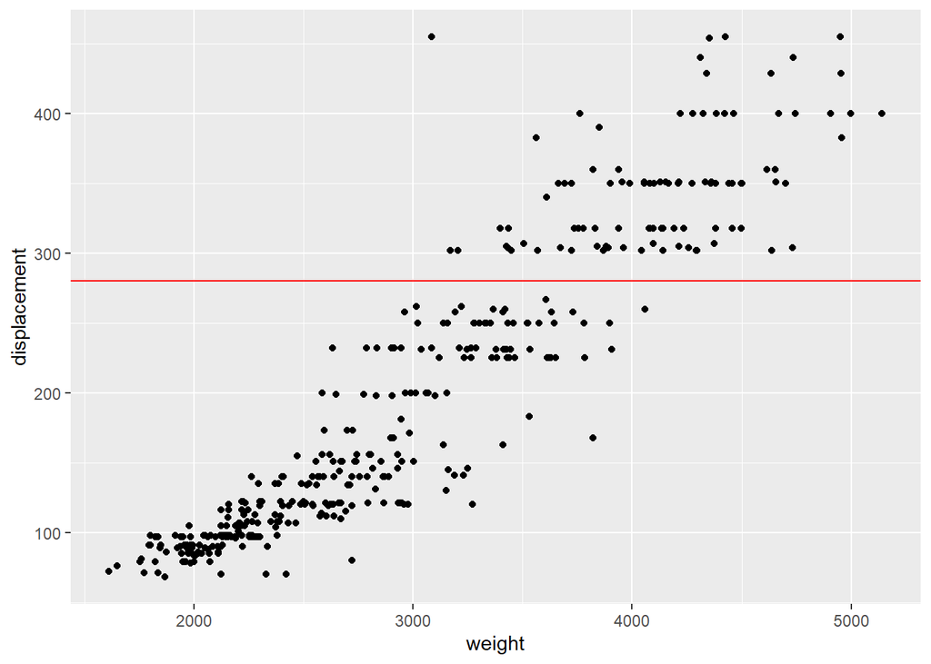

```r
gp <- ggplot(data = Auto, aes(x = weight, y = displacement))
gp <- gp + geom_point() + geom_abline(slope = 0, intercept = 280, col = 'red')
gp
```